# Sixth Week: Linear Models

House price prediction

مهسا خوش نما 93101481

2018-04-14 21:35:23

> با توجه به داده های قیمت منازل لطفا با سوالات زیر پاسخ دهید.

```r
library(readr)
library(dplyr)
library(ggplot2)
library(Hmisc)
library(reshape2)
library(gridExtra)
library(corrplot)
library(car)
library(knitr)
library(kableExtra)

house = read_csv("F:/University/8th Semester/Data Analysis/Class/Week 6/house/train.csv")
```

۱. ماتریس همبستگی متغیرهای مختلف را به دست آورده و سپس رسم نمایید. اعداد به دست آمده را با آزمون فرض معناداری همبستگی بسنجید و سپس ده متغیری که همبستگی بالاتری با قیمت دارند را مشخص نمایید.

### پاسخ:

بااستفاده از تابع rcorr همبستگی و همچنین p-value آزمون همبستگی را برای دو به دوی متغیرها به دست می آوریم. با توجه به این که فرض صفر این آزمون، صفر بودن همبستگی است هرچه مقدار p-value کمتر باشد همبستگی به دست آمده در صورتی که مقدارش قابل توجه باشد،معتبرتر است.

```r
house %>% mutate(age = 2018 - YearBuilt) -> house
house %>% select_if(is.numeric) %>% select(-YearBuilt) %>%  .[,-1] -> stat
corr = rcorr(as.matrix(stat))
corr_matrix = corr[[1]]
pvalue_matrix = corr[[3]]
kable(corr_matrix) %>%  kable_styling() %>%
  scroll_box(width = "900px", height = "600px")
```

|  | MSSubClass | LotFrontage | LotArea | OverallQual | OverallCond | YearRemodAdd | MasVnrArea | BsmtFinSF1 | BsmtFinSF2 | BsmtUnfSF | TotalBsmtSF | 1stFlrSF | 2ndFlrSF | LowQualFinSF | GrLivArea | BsmtFullBath | BsmtHalfBath | FullBath | HalfBath | BedroomAbvGr | KitchenAbvGr | TotRmsAbvGrd | Fireplaces | GarageYrBlt | GarageCars | GarageArea | WoodDeckSF | OpenPorchSF | EnclosedPorch | … |
| --- | --- | --- | --- | --- | --- | --- | --- | --- | --- | --- | --- | --- | --- | --- | --- | --- | --- | --- | --- | --- | --- | --- | --- | --- | --- | --- | --- | --- | --- | --- |
| MSSubClass | 1.0000000 | -0.3863469 | -0.1397811 | 0.0326277 | -0.0593158 | 0.0405810 | 0.0229363 | -0.0698357 | -0.0656486 | -0.1407595 | -0.2385184 | -0.2517584 | 0.3078857 | 0.0464738 | 0.0748532 | 0.0034910 | -0.0023325 | 0.1316082 | 0.1773544 | -0.0234380 | 0.2817210 | 0.0403801 | -0.0455693 | 0.0850719 | -0.0401098 | -0.0986715 | -0.0125794 | -0.0061001 | -0.0120366 | … |
| LotFrontage | -0.3863469 | 1.0000000 | 0.4260950 | 0.2516458 | -0.0592135 | 0.0888656 | 0.1934581 | 0.2336332 | 0.0498997 | 0.1326437 | 0.3920746 | 0.4571810 | 0.0801773 | 0.0384685 | 0.4027974 | 0.1009486 | -0.0072343 | 0.1987687 | 0.0535319 | 0.2631699 | -0.0060688 | 0.3520959 | 0.2666395 | 0.0702498 | 0.2856909 | 0.3449967 | 0.0885209 | 0.1519722 | 0.0107003 | … |
| LotArea | -0.1397811 | 0.4260950 | 1.0000000 | 0.1058057 | -0.0056363 | 0.0137884 | 0.1041598 | 0.2141031 | 0.1111697 | -0.0026184 | 0.2608331 | 0.2994746 | 0.0509859 | 0.0047790 | 0.2631162 | 0.1581545 | 0.0480456 | 0.1260306 | 0.0142595 | 0.1196899 | -0.0177839 | 0.1900148 | 0.2713640 | -0.0249474 | 0.1548707 | 0.1804028 | 0.1716977 | 0.0847738 | -0.0183397 | … |
| OverallQual | 0.0326277 | 0.2516458 | 0.1058057 | 1.0000000 | -0.0919323 | 0.5506839 | 0.4118757 | 0.2396660 | -0.0591187 | 0.3081589 | 0.5378085 | 0.4762238 | 0.2954929 | -0.0304293 | 0.5930074 | 0.1110978 | -0.0401502 | 0.5505997 | 0.2734581 | 0.1016764 | -0.1838822 | 0.4274523 | 0.3967650 | 0.5477658 | 0.6006707 | 0.5620218 | 0.2389234 | 0.3088188 | -0.1139369 | … |
| OverallCond | -0.0593158 | -0.0592135 | -0.0056363 | -0.0919323 | 1.0000000 | 0.0737415 | -0.1281012 | -0.0462309 | 0.0402292 | -0.1368406 | -0.1710975 | -0.1442028 | 0.0289421 | 0.0254943 | -0.0796859 | -0.0549415 | 0.1178209 | -0.1941495 | -0.0607693 | 0.0129801 | -0.0870009 | -0.0575832 | -0.0238200 | -0.3242967 | -0.1857575 | -0.1515214 | -0.0033337 | -0.0325888 | 0.0703562 | … |
| YearRemodAdd | 0.0405810 | 0.0888656 | 0.0137884 | 0.5506839 | 0.0737415 | 1.0000000 | 0.1796184 | 0.1284505 | -0.0677585 | 0.1811331 | 0.2910656 | 0.2403793 | 0.1400238 | -0.0624191 | 0.2873885 | 0.1194699 | -0.0123370 | 0.4390465 | 0.1833306 | -0.0405809 | -0.1495975 | 0.1917398 | 0.1125813 | 0.6422768 | 0.4206222 | 0.3715998 | 0.2057259 | 0.2262976 | -0.1939191 | … |
| MasVnrArea | 0.0229363 | 0.1934581 | 0.1041598 | 0.4118757 | -0.1281012 | 0.1796184 | 1.0000000 | 0.2647363 | -0.0723188 | 0.1144421 | 0.3639362 | 0.3445007 | 0.1745615 | -0.0690709 | 0.3908566 | 0.0853098 | 0.0266728 | 0.2768328 | 0.2014439 | 0.1028212 | -0.0376103 | 0.2806817 | 0.2490696 | 0.2526908 | 0.3642036 | 0.3730665 | 0.1597181 | 0.1257028 | -0.1102038 | … |
| BsmtFinSF1 | -0.0698357 | 0.2336332 | 0.2141031 | 0.2396660 | -0.0462309 | 0.1284505 | 0.2647363 | 1.0000000 | -0.0501174 | -0.4952515 | 0.5223961 | 0.4458627 | -0.1370790 | -0.0645026 | 0.2081711 | 0.6492118 | 0.0674185 | 0.0585431 | 0.0042624 | -0.1073547 | -0.0810069 | 0.0443156 | 0.2600109 | 0.1534841 | 0.2240535 | 0.2969704 | 0.2043061 | 0.1117606 | -0.1023033 | … |
| BsmtFinSF2 | -0.0656486 | 0.0498997 | 0.1111697 | -0.0591187 | 0.0402292 | -0.0677585 | -0.0723188 | -0.0501174 | 1.0000000 | -0.2092945 | 0.1048095 | 0.0971174 | -0.0992603 | 0.0148070 | -0.0096399 | 0.1586781 | 0.0709481 | -0.0764439 | -0.0321478 | -0.0157281 | -0.0407512 | -0.0352265 | 0.0469207 | -0.0880108 | -0.0382635 | -0.0182266 | 0.0678983 | 0.0030926 | 0.0365433 | … |
| BsmtUnfSF | -0.1407595 | 0.1326437 | -0.0026184 | 0.3081589 | -0.1368406 | 0.1811331 | 0.1144421 | -0.4952515 | -0.2092945 | 1.0000000 | 0.4153596 | 0.3179874 | 0.0044691 | 0.0281667 | 0.2402573 | -0.4229005 | -0.0958043 | 0.2888861 | -0.0411175 | 0.1666433 | 0.0300859 | 0.2506471 | 0.0515749 | 0.1907083 | 0.2141752 | 0.1833027 | -0.0053164 | 0.1290054 | -0.0025379 | … |
| TotalBsmtSF | -0.2385184 | 0.3920746 | 0.2608331 | 0.5378085 | -0.1710975 | 0.2910656 | 0.3639362 | 0.5223961 | 0.1048095 | 0.4153596 | 1.0000000 | 0.8195300 | -0.1745120 | -0.0332454 | 0.4548682 | 0.3073506 | -0.0003146 | 0.3237224 | -0.0488037 | 0.0504500 | -0.0689006 | 0.2855726 | 0.3395193 | 0.3224452 | 0.4345848 | 0.4866655 | 0.2320186 | 0.2472637 | -0.0954777 | … |
| 1stFlrSF | -0.2517584 | 0.4571810 | 0.2994746 | 0.4762238 | -0.1442028 | 0.2403793 | 0.3445007 | 0.4458627 | 0.0971174 | 0.3179874 | 0.8195300 | 1.0000000 | -0.2026462 | -0.0142407 | 0.5660240 | 0.2446711 | 0.0019557 | 0.3806375 | -0.1199159 | 0.1274007 | 0.0681006 | 0.4095160 | 0.4105311 | 0.2334491 | 0.4393168 | 0.4897817 | 0.2354586 | 0.2116712 | -0.0652917 | … |
| 2ndFlrSF | 0.3078857 | 0.0801773 | 0.0509859 | 0.2954929 | 0.0289421 | 0.1400238 | 0.1745615 | -0.1370790 | -0.0992603 | 0.0044691 | -0.1745120 | -0.2026462 | 1.0000000 | 0.0633530 | 0.6875011 | -0.1694940 | -0.0238548 | 0.4213780 | 0.6097073 | 0.5029006 | 0.0593058 | 0.6164226 | 0.1945609 | 0.0708323 | 0.1839256 | 0.1383470 | 0.0921654 | 0.2080261 | 0.0619887 | … |
| LowQualFinSF | 0.0464738 | 0.0384685 | 0.0047790 | -0.0304293 | 0.0254943 | -0.0624191 | -0.0690709 | -0.0645026 | 0.0148070 | 0.0281667 | -0.0332454 | -0.0142407 | 0.0633530 | 1.0000000 | 0.1346828 | -0.0471434 | -0.0058415 | -0.0007095 | -0.0270800 | 0.1056066 | 0.0075217 | 0.1311848 | -0.0212721 | -0.0363632 | -0.0944795 | -0.0676014 | -0.0254436 | 0.0182510 | 0.0610812 | … |
| GrLivArea | 0.0748532 | 0.4027974 | 0.2631162 | 0.5930074 | -0.0796859 | 0.2873885 | 0.3908566 | 0.2081711 | -0.0096399 | 0.2402573 | 0.4548682 | 0.5660240 | 0.6875011 | 0.1346828 | 1.0000000 | 0.0348360 | -0.0189185 | 0.6300116 | 0.4157716 | 0.5212695 | 0.1000632 | 0.8254894 | 0.4616791 | 0.2311967 | 0.4672474 | 0.4689975 | 0.2474328 | 0.3302240 | 0.0091132 | … |
| BsmtFullBath | 0.0034910 | 0.1009486 | 0.1581545 | 0.1110978 | -0.0549415 | 0.1194699 | 0.0853098 | 0.6492118 | 0.1586781 | -0.4229005 | 0.3073506 | 0.2446711 | -0.1694940 | -0.0471434 | 0.0348360 | 1.0000000 | -0.1478710 | -0.0645120 | -0.0309050 | -0.1506728 | -0.0415025 | -0.0532752 | 0.1379277 | 0.1245525 | 0.1318812 | 0.1791895 | 0.1753152 | 0.0673415 | -0.0499106 | … |
| BsmtHalfBath | -0.0023325 | -0.0072343 | 0.0480456 | -0.0401502 | 0.1178209 | -0.0123370 | 0.0266728 | 0.0674185 | 0.0709481 | -0.0958043 | -0.0003146 | 0.0019557 | -0.0238548 | -0.0058415 | -0.0189185 | -0.1478710 | 1.0000000 | -0.0545358 | -0.0123399 | 0.0465188 | -0.0379444 | -0.0238363 | 0.0289756 | -0.0774636 | -0.0208911 | -0.0245356 | 0.0401612 | -0.0253238 | -0.0085553 | … |
| FullBath | 0.1316082 | 0.1987687 | 0.1260306 | 0.5505997 | -0.1941495 | 0.4390465 | 0.2768328 | 0.0585431 | -0.0764439 | 0.2888861 | 0.3237224 | 0.3806375 | 0.4213780 | -0.0007095 | 0.6300116 | -0.0645120 | -0.0545358 | 1.0000000 | 0.1363806 | 0.3632520 | 0.1331152 | 0.5547843 | 0.2436705 | 0.4845574 | 0.4696720 | 0.4056562 | 0.1877032 | 0.2599774 | -0.1150930 | … |
| HalfBath | 0.1773544 | 0.0535319 | 0.0142595 | 0.2734581 | -0.0607693 | 0.1833306 | 0.2014439 | 0.0042624 | -0.0321478 | -0.0411175 | -0.0488037 | -0.1199159 | 0.6097073 | -0.0270800 | 0.4157716 | -0.0309050 | -0.0123399 | 0.1363806 | 1.0000000 | 0.2266515 | -0.0682625 | 0.3434149 | 0.2036485 | 0.1967852 | 0.2191782 | 0.1635494 | 0.1080803 | 0.1997401 | -0.0953165 | … |
| BedroomAbvGr | -0.0234380 | 0.2631699 | 0.1196899 | 0.1016764 | 0.0129801 | -0.0405809 | 0.1028212 | -0.1073547 | -0.0157281 | 0.1666433 | 0.0504500 | 0.1274007 | 0.5029006 | 0.1056066 | 0.5212695 | -0.1506728 | 0.0465188 | 0.3632520 | 0.2266515 | 1.0000000 | 0.1985968 | 0.6766199 | 0.1075697 | -0.0645184 | 0.0861064 | 0.0652525 | 0.0468538 | 0.0938096 | 0.0415704 | … |
| KitchenAbvGr | 0.2817210 | -0.0060688 | -0.0177839 | -0.1838822 | -0.0870009 | -0.1495975 | -0.0376103 | -0.0810069 | -0.0407512 | 0.0300859 | -0.0689006 | 0.0681006 | 0.0593058 | 0.0075217 | 0.1000632 | -0.0415025 | -0.0379444 | 0.1331152 | -0.0682625 | 0.1985968 | 1.0000000 | 0.2560454 | -0.1239362 | -0.1244114 | -0.0506339 | -0.0644330 | -0.0901303 | -0.0700906 | 0.0373124 | … |
| TotRmsAbvGrd | 0.0403801 | 0.3520959 | 0.1900148 | 0.4274523 | -0.0575832 | 0.1917398 | 0.2806817 | 0.0443156 | -0.0352265 | 0.2506471 | 0.2855726 | 0.4095160 | 0.6164226 | 0.1311848 | 0.8254894 | -0.0532752 | -0.0238363 | 0.5547843 | 0.3434149 | 0.6766199 | 0.2560454 | 1.0000000 | 0.3261145 | 0.1481117 | 0.3622886 | 0.3378221 | 0.1659839 | 0.2341916 | 0.0041513 | … |
| Fireplaces | -0.0455693 | 0.2666395 | 0.2713640 | 0.3967650 | -0.0238200 | 0.1125813 | 0.2490696 | 0.2600109 | 0.0469207 | 0.0515749 | 0.3395193 | 0.4105311 | 0.1945609 | -0.0212721 | 0.4616791 | 0.1379277 | 0.0289756 | 0.2436705 | 0.2036485 | 0.1075697 | -0.1239362 | 0.3261145 | 1.0000000 | 0.0468216 | 0.3007888 | 0.2691412 | 0.2000188 | 0.1694053 | -0.0248219 | … |
| GarageYrBlt | 0.0850719 | 0.0702498 | -0.0249474 | 0.5477658 | -0.3242967 | 0.6422768 | 0.2526908 | 0.1534841 | -0.0880108 | 0.1907083 | 0.3224452 | 0.2334491 | 0.0708323 | -0.0363632 | 0.2311967 | 0.1245525 | -0.0774636 | 0.4845574 | 0.1967852 | -0.0645184 | -0.1244114 | 0.1481117 | 0.0468216 | 1.0000000 | 0.5889200 | 0.5645671 | 0.2245770 | 0.2284246 | -0.2970026 | … |
| GarageCars | -0.0401098 | 0.2856909 | 0.1548707 | 0.6006707 | -0.1857575 | 0.4206222 | 0.3642036 | 0.2240535 | -0.0382635 | 0.2141752 | 0.4345848 | 0.4393168 | 0.1839256 | -0.0944795 | 0.4672474 | 0.1318812 | -0.0208911 | 0.4696720 | 0.2191782 | 0.0861064 | -0.0506339 | 0.3622886 | 0.3007888 | 0.5889200 | 1.0000000 | 0.8824754 | 0.2263421 | 0.2135694 | -0.1514342 | … |
| GarageArea | -0.0986715 | 0.3449967 | 0.1804028 | 0.5620218 | -0.1515214 | 0.3715998 | 0.3730665 | 0.2969704 | -0.0182266 | 0.1833027 | 0.4866655 | 0.4897817 | 0.1383470 | -0.0676014 | 0.4689975 | 0.1791895 | -0.0245356 | 0.4056562 | 0.1635494 | 0.0652525 | -0.0644330 | 0.3378221 | 0.2691412 | 0.5645671 | 0.8824754 | 1.0000000 | 0.2246663 | 0.2414347 | -0.1217767 | … |
| WoodDeckSF | -0.0125794 | 0.0885209 | 0.1716977 | 0.2389234 | -0.0033337 | 0.2057259 | 0.1597181 | 0.2043061 | 0.0678983 | -0.0053164 | 0.2320186 | 0.2354586 | 0.0921654 | -0.0254436 | 0.2474328 | 0.1753152 | 0.0401612 | 0.1877032 | 0.1080803 | 0.0468538 | -0.0901303 | 0.1659839 | 0.2000188 | 0.2245770 | 0.2263421 | 0.2246663 | 1.0000000 | 0.0586606 | -0.1259889 | … |
| OpenPorchSF | -0.0061001 | 0.1519722 | 0.0847738 | 0.3088188 | -0.0325888 | 0.2262976 | 0.1257028 | 0.1117606 | 0.0030926 | 0.1290054 | 0.2472637 | 0.2116712 | 0.2080261 | 0.0182510 | 0.3302240 | 0.0673415 | -0.0253238 | 0.2599774 | 0.1997401 | 0.0938096 | -0.0700906 | 0.2341916 | 0.1694053 | 0.2284246 | 0.2135694 | 0.2414347 | 0.0586606 | 1.0000000 | -0.0930793 | … |
| EnclosedPorch | -0.0120366 | 0.0107003 | -0.0183397 | -0.1139369 | 0.0703562 | -0.1939191 | -0.1102038 | -0.1023033 | 0.0365433 | -0.0025379 | -0.0954777 | -0.0652917 | 0.0619887 | 0.0610812 | 0.0091132 | -0.0499106 | -0.0085553 | -0.1150930 | -0.0953165 | 0.0415704 | 0.0373124 | 0.0041513 | -0.0248219 | -0.2970026 | -0.1514342 | -0.1217767 | -0.1259889 | -0.0930793 | 1.0000000 | … |
| 3SsnPorch | -0.0438245 | 0.0700292 | 0.0204228 | 0.0303706 | 0.0255037 | 0.0452858 | 0.0187955 | 0.0264505 | -0.0299934 | 0.0207640 | 0.0373837 | 0.0561044 | -0.0243576 | -0.0042956 | 0.0206432 | -0.0001061 | 0.0351136 | 0.0353530 | -0.0049725 | -0.0244778 | -0.0246004 | -0.0066832 | 0.0112572 | 0.0235437 | 0.0357653 | 0.0350867 | -0.0327706 | -0.0058425 | -0.0373053 | … |
| ScreenPorch | -0.0260302 | 0.0413828 | 0.0431604 | 0.0648864 | 0.0548105 | -0.0387400 | 0.0614655 | 0.0620206 | 0.0888713 | -0.0125793 | 0.0844890 | 0.0887581 | 0.0406064 | 0.0267994 | 0.1015104 | 0.0231477 | 0.0321214 | -0.0081061 | 0.0724258 | 0.0442997 | -0.0516134 | 0.0593826 | 0.1845303 | -0.0754175 | 0.0504938 | 0.0514118 | -0.0741814 | 0.0743039 | -0.0828642 | … |
| PoolArea | 0.0082827 | 0.2061668 | 0.0776724 | 0.0651658 | -0.0019849 | 0.0058294 | 0.0117231 | 0.1404913 | 0.0417091 | -0.0350922 | 0.1260531 | 0.1315250 | 0.0814869 | 0.0621574 | 0.1702053 | 0.0676156 | 0.0200246 | 0.0496038 | 0.0223815 | 0.0707026 | -0.0145251 | 0.0837573 | 0.0950735 | -0.0145007 | 0.0209335 | 0.0610473 | 0.0733782 | 0.0607621 | 0.0542026 | … |
| MiscVal | -0.0076833 | 0.0033676 | 0.0380677 | -0.0314062 | 0.0687768 | -0.0102862 | -0.0298154 | 0.0035715 | 0.0049398 | -0.0238366 | -0.0184789 | -0.0210957 | 0.0161969 | -0.0037929 | -0.0024156 | -0.0230470 | -0.0073665 | -0.0142898 | 0.0012901 | 0.0077670 | 0.0623407 | 0.0247629 | 0.0014086 | -0.0324175 | -0.0430801 | -0.0273999 | -0.0095512 | -0.0185837 | 0.0183606 | … |
| MoSold | -0.0135846 | 0.0112000 | 0.0012050 | 0.0708152 | -0.0035108 | 0.0214900 | -0.0059647 | -0.0157269 | -0.0152107 | 0.0348884 | 0.0131962 | 0.0313716 | 0.0351644 | -0.0221740 | 0.0502397 | -0.0253609 | 0.0328727 | 0.0558721 | -0.0090499 | 0.0465439 | 0.0265889 | 0.0369071 | 0.0463571 | 0.0053370 | 0.0405217 | 0.0279738 | 0.0210110 | 0.0712549 | -0.0288873 | … |
| YrSold | -0.0214070 | 0.0074496 | -0.0142614 | -0.0273467 | 0.0439497 | 0.0357432 | -0.0082010 | 0.0143589 | 0.0317056 | -0.0412582 | -0.0149686 | -0.0136038 | -0.0286999 | -0.0289209 | -0.0365258 | 0.0670491 | -0.0465239 | -0.0196688 | -0.0102687 | -0.0360139 | 0.0316872 | -0.0345164 | -0.0240956 | -0.0010143 | -0.0391169 | -0.0273779 | 0.0222705 | -0.0576194 | -0.0099159 | … |
| SalePrice | -0.0842841 | 0.3517991 | 0.2638434 | 0.7909816 | -0.0778559 | 0.5071010 | 0.4774930 | 0.3864198 | -0.0113781 | 0.2144791 | 0.6135806 | 0.6058522 | 0.3193338 | -0.0256061 | 0.7086245 | 0.2271222 | -0.0168442 | 0.5606638 | 0.2841077 | 0.1682132 | -0.1359074 | 0.5337232 | 0.4669288 | 0.4863617 | 0.6404092 | 0.6234314 | 0.3244134 | 0.3158562 | -0.1285780 | … |
| age | -0.0278501 | -0.1233495 | -0.0142277 | -0.5723228 | 0.3759832 | -0.5928550 | -0.3157071 | -0.2495032 | 0.0491068 | -0.1490404 | -0.3914520 | -0.2819859 | -0.0103077 | 0.1837843 | -0.1990097 | -0.1875985 | 0.0381618 | -0.4682708 | -0.2426559 | 0.0706512 | 0.1748002 | -0.0955891 | -0.1477164 | -0.8256675 | -0.5378501 | -0.4789538 | -0.2248801 | -0.1886858 | 0.3872678 | … |

```r
kable(pvalue_matrix) %>%  kable_styling() %>%
  scroll_box(width = "900px", height = "600px")
```

|  | MSSubClass | LotFrontage | LotArea | OverallQual | OverallCond | YearRemodAdd | MasVnrArea | BsmtFinSF1 | BsmtFinSF2 | BsmtUnfSF | TotalBsmtSF | 1stFlrSF | 2ndFlrSF | LowQualFinSF | GrLivArea | BsmtFullBath | BsmtHalfBath | FullBath | HalfBath | BedroomAbvGr | KitchenAbvGr | TotRmsAbvGrd | Fireplaces | GarageYrBlt | GarageCars | GarageArea | WoodDeckSF | OpenPorchSF | EnclosedPorch | … |
| --- | --- | --- | --- | --- | --- | --- | --- | --- | --- | --- | --- | --- | --- | --- | --- | --- | --- | --- | --- | --- | --- | --- | --- | --- | --- | --- | --- | --- | --- | --- |
| MSSubClass | NA | 0.0000000 | 0.0000001 | 0.2127766 | 0.0234203 | 0.1211631 | 0.3824712 | 0.0075988 | 0.0121078 | 0.0000001 | 0.0000000 | 0.0000000 | 0.0000000 | 0.0758652 | 0.0042137 | 0.8939735 | 0.9290423 | 0.0000005 | 0.0000000 | 0.3708290 | 0.0000000 | 0.1230183 | 0.0817511 | 0.0015669 | 0.1255479 | 0.0001592 | 0.6310397 | 0.8158485 | 0.6458454 | … |
| LotFrontage | 0.0000000 | NA | 0.0000000 | 0.0000000 | 0.0401957 | 0.0020522 | 0.0000000 | 0.0000000 | 0.0838858 | 0.0000040 | 0.0000000 | 0.0000000 | 0.0054332 | 0.1827783 | 0.0000000 | 0.0004588 | 0.8022392 | 0.0000000 | 0.0636579 | 0.0000000 | 0.8335889 | 0.0000000 | 0.0000000 | 0.0183420 | 0.0000000 | 0.0000000 | 0.0021365 | 0.0000001 | 0.7110477 | … |
| LotArea | 0.0000001 | 0.0000000 | NA | 0.0000511 | 0.8296279 | 0.5985903 | 0.0000700 | 0.0000000 | 0.0000207 | 0.9203746 | 0.0000000 | 0.0000000 | 0.0514427 | 0.8552305 | 0.0000000 | 0.0000000 | 0.0664603 | 0.0000014 | 0.5861562 | 0.0000045 | 0.4971427 | 0.0000000 | 0.0000000 | 0.3545896 | 0.0000000 | 0.0000000 | 0.0000000 | 0.0011858 | 0.4837906 | … |
| OverallQual | 0.2127766 | 0.0000000 | 0.0000511 | NA | 0.0004362 | 0.0000000 | 0.0000000 | 0.0000000 | 0.0238857 | 0.0000000 | 0.0000000 | 0.0000000 | 0.0000000 | 0.2452458 | 0.0000000 | 0.0000209 | 0.1251676 | 0.0000000 | 0.0000000 | 0.0000995 | 0.0000000 | 0.0000000 | 0.0000000 | 0.0000000 | 0.0000000 | 0.0000000 | 0.0000000 | 0.0000000 | 0.0000128 | … |
| OverallCond | 0.0234203 | 0.0401957 | 0.8296279 | 0.0004362 | NA | 0.0048161 | 0.0000010 | 0.0774110 | 0.1244256 | 0.0000002 | 0.0000000 | 0.0000000 | 0.2690898 | 0.3303245 | 0.0023111 | 0.0358081 | 0.0000064 | 0.0000000 | 0.0202248 | 0.6202024 | 0.0008755 | 0.0277934 | 0.3630812 | 0.0000000 | 0.0000000 | 0.0000000 | 0.8987253 | 0.2133227 | 0.0071594 | … |
| YearRemodAdd | 0.1211631 | 0.0020522 | 0.5985903 | 0.0000000 | 0.0048161 | NA | 0.0000000 | 0.0000008 | 0.0096029 | 0.0000000 | 0.0000000 | 0.0000000 | 0.0000001 | 0.0170646 | 0.0000000 | 0.0000047 | 0.6376325 | 0.0000000 | 0.0000000 | 0.1211642 | 0.0000000 | 0.0000000 | 0.0000162 | 0.0000000 | 0.0000000 | 0.0000000 | 0.0000000 | 0.0000000 | 0.0000000 | … |
| MasVnrArea | 0.3824712 | 0.0000000 | 0.0000700 | 0.0000000 | 0.0000010 | 0.0000000 | NA | 0.0000000 | 0.0058342 | 0.0000123 | 0.0000000 | 0.0000000 | 0.0000000 | 0.0084676 | 0.0000000 | 0.0011384 | 0.3097834 | 0.0000000 | 0.0000000 | 0.0000867 | 0.1520249 | 0.0000000 | 0.0000000 | 0.0000000 | 0.0000000 | 0.0000000 | 0.0000000 | 0.0000015 | 0.0000257 | … |
| BsmtFinSF1 | 0.0075988 | 0.0000000 | 0.0000000 | 0.0000000 | 0.0774110 | 0.0000008 | 0.0000000 | NA | 0.0555504 | 0.0000000 | 0.0000000 | 0.0000000 | 0.0000001 | 0.0136976 | 0.0000000 | 0.0000000 | 0.0099725 | 0.0252907 | 0.8707324 | 0.0000395 | 0.0019502 | 0.0905166 | 0.0000000 | 0.0000000 | 0.0000000 | 0.0000000 | 0.0000000 | 0.0000187 | 0.0000901 | … |
| BsmtFinSF2 | 0.0121078 | 0.0838858 | 0.0000207 | 0.0238857 | 0.1244256 | 0.0096029 | 0.0058342 | 0.0555504 | NA | 0.0000000 | 0.0000601 | 0.0002020 | 0.0001454 | 0.5718554 | 0.7128488 | 0.0000000 | 0.0066874 | 0.0034702 | 0.2195850 | 0.5481779 | 0.1196093 | 0.1785383 | 0.0730866 | 0.0010692 | 0.1439250 | 0.4864925 | 0.0094546 | 0.9060156 | 0.1628382 | … |
| BsmtUnfSF | 0.0000001 | 0.0000040 | 0.9203746 | 0.0000000 | 0.0000002 | 0.0000000 | 0.0000123 | 0.0000000 | 0.0000000 | NA | 0.0000000 | 0.0000000 | 0.8645239 | 0.2821334 | 0.0000000 | 0.0000000 | 0.0002464 | 0.0000000 | 0.1163181 | 0.0000000 | 0.2506158 | 0.0000000 | 0.0488044 | 0.0000000 | 0.0000000 | 0.0000000 | 0.8391603 | 0.0000008 | 0.9228150 | … |
| TotalBsmtSF | 0.0000000 | 0.0000000 | 0.0000000 | 0.0000000 | 0.0000000 | 0.0000000 | 0.0000000 | 0.0000000 | 0.0000601 | 0.0000000 | NA | 0.0000000 | 0.0000000 | 0.2042388 | 0.0000000 | 0.0000000 | 0.9904177 | 0.0000000 | 0.0622793 | 0.0539464 | 0.0084494 | 0.0000000 | 0.0000000 | 0.0000000 | 0.0000000 | 0.0000000 | 0.0000000 | 0.0000000 | 0.0002588 | … |
| 1stFlrSF | 0.0000000 | 0.0000000 | 0.0000000 | 0.0000000 | 0.0000000 | 0.0000000 | 0.0000000 | 0.0000000 | 0.0002020 | 0.0000000 | 0.0000000 | NA | 0.0000000 | 0.5866501 | 0.0000000 | 0.0000000 | 0.9404841 | 0.0000000 | 0.0000043 | 0.0000010 | 0.0092435 | 0.0000000 | 0.0000000 | 0.0000000 | 0.0000000 | 0.0000000 | 0.0000000 | 0.0000000 | 0.0125844 | … |
| 2ndFlrSF | 0.0000000 | 0.0054332 | 0.0514427 | 0.0000000 | 0.2690898 | 0.0000001 | 0.0000000 | 0.0000001 | 0.0001454 | 0.8645239 | 0.0000000 | 0.0000000 | NA | 0.0154748 | 0.0000000 | 0.0000000 | 0.3623802 | 0.0000000 | 0.0000000 | 0.0000000 | 0.0234438 | 0.0000000 | 0.0000000 | 0.0085066 | 0.0000000 | 0.0000001 | 0.0004217 | 0.0000000 | 0.0178443 | … |
| LowQualFinSF | 0.0758652 | 0.1827783 | 0.8552305 | 0.2452458 | 0.3303245 | 0.0170646 | 0.0084676 | 0.0136976 | 0.5718554 | 0.2821334 | 0.2042388 | 0.5866501 | 0.0154748 | NA | 0.0000002 | 0.0717335 | 0.8235244 | 0.9783903 | 0.3011219 | 0.0000528 | 0.7739873 | 0.0000005 | 0.4166751 | 0.1771551 | 0.0003003 | 0.0097721 | 0.3312869 | 0.4859080 | 0.0195909 | … |
| GrLivArea | 0.0042137 | 0.0000000 | 0.0000000 | 0.0000000 | 0.0023111 | 0.0000000 | 0.0000000 | 0.0000000 | 0.7128488 | 0.0000000 | 0.0000000 | 0.0000000 | 0.0000000 | 0.0000002 | NA | 0.1834039 | 0.4700979 | 0.0000000 | 0.0000000 | 0.0000000 | 0.0001283 | 0.0000000 | 0.0000000 | 0.0000000 | 0.0000000 | 0.0000000 | 0.0000000 | 0.0000000 | 0.7278971 | … |
| BsmtFullBath | 0.8939735 | 0.0004588 | 0.0000000 | 0.0000209 | 0.0358081 | 0.0000047 | 0.0011384 | 0.0000000 | 0.0000000 | 0.0000000 | 0.0000000 | 0.0000000 | 0.0000000 | 0.0717335 | 0.1834039 | NA | 0.0000000 | 0.0136838 | 0.2379416 | 0.0000000 | 0.1129357 | 0.0418161 | 0.0000001 | 0.0000035 | 0.0000004 | 0.0000000 | 0.0000000 | 0.0100579 | 0.0565675 | … |
| BsmtHalfBath | 0.9290423 | 0.8022392 | 0.0664603 | 0.1251676 | 0.0000064 | 0.6376325 | 0.3097834 | 0.0099725 | 0.0066874 | 0.0002464 | 0.9904177 | 0.9404841 | 0.3623802 | 0.8235244 | 0.4700979 | 0.0000000 | NA | 0.0371987 | 0.6375543 | 0.0755810 | 0.1473008 | 0.3627516 | 0.2685363 | 0.0039980 | 0.4250739 | 0.3488402 | 0.1250634 | 0.3335712 | 0.7439517 | … |
| FullBath | 0.0000005 | 0.0000000 | 0.0000014 | 0.0000000 | 0.0000000 | 0.0000000 | 0.0000000 | 0.0252907 | 0.0034702 | 0.0000000 | 0.0000000 | 0.0000000 | 0.0000000 | 0.9783903 | 0.0000000 | 0.0136838 | 0.0371987 | NA | 0.0000002 | 0.0000000 | 0.0000003 | 0.0000000 | 0.0000000 | 0.0000000 | 0.0000000 | 0.0000000 | 0.0000000 | 0.0000000 | 0.0000104 | … |
| HalfBath | 0.0000000 | 0.0636579 | 0.5861562 | 0.0000000 | 0.0202248 | 0.0000000 | 0.0000000 | 0.8707324 | 0.2195850 | 0.1163181 | 0.0622793 | 0.0000043 | 0.0000000 | 0.3011219 | 0.0000000 | 0.2379416 | 0.6375543 | 0.0000002 | NA | 0.0000000 | 0.0090776 | 0.0000000 | 0.0000000 | 0.0000000 | 0.0000000 | 0.0000000 | 0.0000350 | 0.0000000 | 0.0002651 | … |
| BedroomAbvGr | 0.3708290 | 0.0000000 | 0.0000045 | 0.0000995 | 0.6202024 | 0.1211642 | 0.0000867 | 0.0000395 | 0.5481779 | 0.0000000 | 0.0539464 | 0.0000010 | 0.0000000 | 0.0000528 | 0.0000000 | 0.0000000 | 0.0755810 | 0.0000000 | 0.0000000 | NA | 0.0000000 | 0.0000000 | 0.0000381 | 0.0165656 | 0.0009898 | 0.0126377 | 0.0734974 | 0.0003316 | 0.1123474 | … |
| KitchenAbvGr | 0.0000000 | 0.8335889 | 0.4971427 | 0.0000000 | 0.0008755 | 0.0000000 | 0.1520249 | 0.0019502 | 0.1196093 | 0.2506158 | 0.0084494 | 0.0092435 | 0.0234438 | 0.7739873 | 0.0001283 | 0.1129357 | 0.1473008 | 0.0000003 | 0.0090776 | 0.0000000 | NA | 0.0000000 | 0.0000020 | 0.0000036 | 0.0530760 | 0.0137998 | 0.0005649 | 0.0073807 | 0.1541632 | … |
| TotRmsAbvGrd | 0.1230183 | 0.0000000 | 0.0000000 | 0.0000000 | 0.0277934 | 0.0000000 | 0.0000000 | 0.0905166 | 0.1785383 | 0.0000000 | 0.0000000 | 0.0000000 | 0.0000000 | 0.0000005 | 0.0000000 | 0.0418161 | 0.3627516 | 0.0000000 | 0.0000000 | 0.0000000 | 0.0000000 | NA | 0.0000000 | 0.0000000 | 0.0000000 | 0.0000000 | 0.0000000 | 0.0000000 | 0.8740741 | … |
| Fireplaces | 0.0817511 | 0.0000000 | 0.0000000 | 0.0000000 | 0.3630812 | 0.0000162 | 0.0000000 | 0.0000000 | 0.0730866 | 0.0488044 | 0.0000000 | 0.0000000 | 0.0000000 | 0.4166751 | 0.0000000 | 0.0000001 | 0.2685363 | 0.0000000 | 0.0000000 | 0.0000381 | 0.0000020 | 0.0000000 | NA | 0.0821944 | 0.0000000 | 0.0000000 | 0.0000000 | 0.0000000 | 0.3432435 | … |
| GarageYrBlt | 0.0015669 | 0.0183420 | 0.3545896 | 0.0000000 | 0.0000000 | 0.0000000 | 0.0000000 | 0.0000000 | 0.0010692 | 0.0000000 | 0.0000000 | 0.0000000 | 0.0085066 | 0.1771551 | 0.0000000 | 0.0000035 | 0.0039980 | 0.0000000 | 0.0000000 | 0.0165656 | 0.0000036 | 0.0000000 | 0.0821944 | NA | 0.0000000 | 0.0000000 | 0.0000000 | 0.0000000 | 0.0000000 | … |
| GarageCars | 0.1255479 | 0.0000000 | 0.0000000 | 0.0000000 | 0.0000000 | 0.0000000 | 0.0000000 | 0.0000000 | 0.1439250 | 0.0000000 | 0.0000000 | 0.0000000 | 0.0000000 | 0.0003003 | 0.0000000 | 0.0000004 | 0.4250739 | 0.0000000 | 0.0000000 | 0.0009898 | 0.0530760 | 0.0000000 | 0.0000000 | 0.0000000 | NA | 0.0000000 | 0.0000000 | 0.0000000 | 0.0000000 | … |
| GarageArea | 0.0001592 | 0.0000000 | 0.0000000 | 0.0000000 | 0.0000000 | 0.0000000 | 0.0000000 | 0.0000000 | 0.4864925 | 0.0000000 | 0.0000000 | 0.0000000 | 0.0000001 | 0.0097721 | 0.0000000 | 0.0000000 | 0.3488402 | 0.0000000 | 0.0000000 | 0.0126377 | 0.0137998 | 0.0000000 | 0.0000000 | 0.0000000 | 0.0000000 | NA | 0.0000000 | 0.0000000 | 0.0000031 | … |
| WoodDeckSF | 0.6310397 | 0.0021365 | 0.0000000 | 0.0000000 | 0.8987253 | 0.0000000 | 0.0000000 | 0.0000000 | 0.0094546 | 0.8391603 | 0.0000000 | 0.0000000 | 0.0004217 | 0.3312869 | 0.0000000 | 0.0000000 | 0.1250634 | 0.0000000 | 0.0000350 | 0.0734974 | 0.0005649 | 0.0000000 | 0.0000000 | 0.0000000 | 0.0000000 | 0.0000000 | NA | 0.0249983 | 0.0000014 | … |
| OpenPorchSF | 0.8158485 | 0.0000001 | 0.0011858 | 0.0000000 | 0.2133227 | 0.0000000 | 0.0000015 | 0.0000187 | 0.9060156 | 0.0000008 | 0.0000000 | 0.0000000 | 0.0000000 | 0.4859080 | 0.0000000 | 0.0100579 | 0.3335712 | 0.0000000 | 0.0000000 | 0.0003316 | 0.0073807 | 0.0000000 | 0.0000000 | 0.0000000 | 0.0000000 | 0.0000000 | 0.0249983 | NA | 0.0003691 | … |
| EnclosedPorch | 0.6458454 | 0.7110477 | 0.4837906 | 0.0000128 | 0.0071594 | 0.0000000 | 0.0000257 | 0.0000901 | 0.1628382 | 0.9228150 | 0.0002588 | 0.0125844 | 0.0178443 | 0.0195909 | 0.7278971 | 0.0565675 | 0.7439517 | 0.0000104 | 0.0002651 | 0.1123474 | 0.1541632 | 0.8740741 | 0.3432435 | 0.0000000 | 0.0000000 | 0.0000031 | 0.0000014 | 0.0003691 | NA | … |
| 3SsnPorch | 0.0941495 | 0.0152097 | 0.4355273 | 0.2461582 | 0.3301473 | 0.0836707 | 0.4742064 | 0.3125032 | 0.2520757 | 0.4278958 | 0.1533766 | 0.0320651 | 0.3523476 | 0.8697349 | 0.4305893 | 0.9967684 | 0.1799353 | 0.1769833 | 0.8494369 | 0.3499768 | 0.3475688 | 0.7986069 | 0.6673530 | 0.3823249 | 0.1719841 | 0.1802697 | 0.2107784 | 0.8234948 | 0.1542417 | … |
| ScreenPorch | 0.3202578 | 0.1517836 | 0.0992478 | 0.0131458 | 0.0362522 | 0.1389957 | 0.0191628 | 0.0177854 | 0.0006749 | 0.6310420 | 0.0012321 | 0.0006857 | 0.1209302 | 0.3061609 | 0.0001022 | 0.3767857 | 0.2199645 | 0.7569616 | 0.0056288 | 0.0906327 | 0.0486360 | 0.0232644 | 0.0000000 | 0.0050775 | 0.0537379 | 0.0495235 | 0.0045690 | 0.0045022 | 0.0015298 | … |
| PoolArea | 0.7518384 | 0.0000000 | 0.0029799 | 0.0127564 | 0.9395944 | 0.8238849 | 0.6553522 | 0.0000001 | 0.1111537 | 0.1802008 | 0.0000014 | 0.0000005 | 0.0018324 | 0.0175350 | 0.0000000 | 0.0097568 | 0.4445328 | 0.0581053 | 0.3927890 | 0.0068797 | 0.5791972 | 0.0013588 | 0.0002749 | 0.5905625 | 0.4241329 | 0.0196591 | 0.0050292 | 0.0202397 | 0.0383751 | … |
| MiscVal | 0.7692691 | 0.9071905 | 0.1459891 | 0.2304122 | 0.0085682 | 0.6945331 | 0.2562107 | 0.8915451 | 0.8504155 | 0.3627454 | 0.4804779 | 0.4205511 | 0.5363168 | 0.8848674 | 0.9265212 | 0.3788657 | 0.7785284 | 0.5853585 | 0.9607167 | 0.7668285 | 0.0172043 | 0.3443919 | 0.9571131 | 0.2289596 | 0.0998784 | 0.2954461 | 0.7153744 | 0.4779915 | 0.4832932 | … |
| MoSold | 0.6040063 | 0.6982030 | 0.9633078 | 0.0067910 | 0.8933753 | 0.4119179 | 0.8203518 | 0.5482075 | 0.5614175 | 0.1827454 | 0.6143911 | 0.2309272 | 0.1793059 | 0.3971934 | 0.0549561 | 0.3328625 | 0.2093598 | 0.0327847 | 0.7297135 | 0.0754238 | 0.3099771 | 0.1586904 | 0.0766044 | 0.8430360 | 0.1217084 | 0.2854434 | 0.4224189 | 0.0064540 | 0.2699986 | … |
| YrSold | 0.4137257 | 0.7964813 | 0.5861053 | 0.2963852 | 0.0932124 | 0.1722487 | 0.7548601 | 0.5835463 | 0.2259960 | 0.1150733 | 0.5676652 | 0.6034971 | 0.2731188 | 0.2694414 | 0.1630401 | 0.0103882 | 0.0755494 | 0.4526681 | 0.6950290 | 0.1690210 | 0.2262661 | 0.1874597 | 0.3575543 | 0.9699819 | 0.1351896 | 0.2958337 | 0.3951420 | 0.0276953 | 0.7050056 | … |
| SalePrice | 0.0012665 | 0.0000000 | 0.0000000 | 0.0000000 | 0.0029124 | 0.0000000 | 0.0000000 | 0.0000000 | 0.6639987 | 0.0000000 | 0.0000000 | 0.0000000 | 0.0000000 | 0.3282073 | 0.0000000 | 0.0000000 | 0.5201536 | 0.0000000 | 0.0000000 | 0.0000000 | 0.0000002 | 0.0000000 | 0.0000000 | 0.0000000 | 0.0000000 | 0.0000000 | 0.0000000 | 0.0000000 | 0.0000008 | … |
| age | 0.2875793 | 0.0000181 | 0.5869923 | 0.0000000 | 0.0000000 | 0.0000000 | 0.0000000 | 0.0000000 | 0.0606698 | 0.0000000 | 0.0000000 | 0.0000000 | 0.6939294 | 0.0000000 | 0.0000000 | 0.0000000 | 0.1449943 | 0.0000000 | 0.0000000 | 0.0069206 | 0.0000000 | 0.0002545 | 0.0000000 | 0.0000000 | 0.0000000 | 0.0000000 | 0.0000000 | 0.0000000 | 0.0000000 | … |

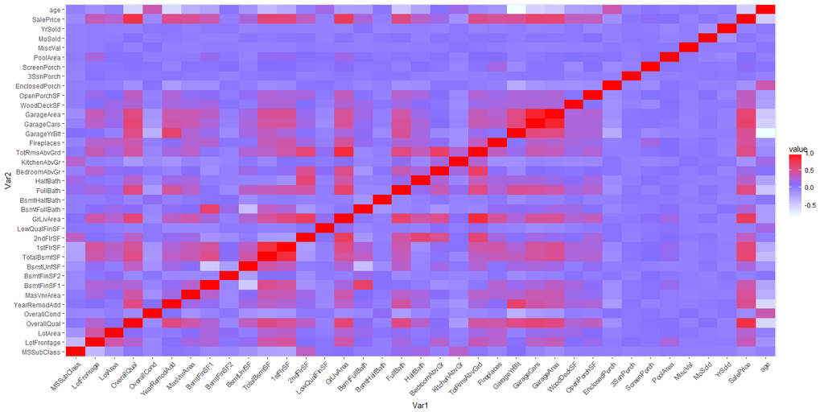

```r
melted_cormat <- melt(corr_matrix)
ggplot(data = melted_cormat, aes(x=Var1, y=Var2, fill=value)) +
  geom_tile() +
  theme(axis.text.x = element_text(angle = 45, hjust = 1, vjust = 1))+
  scale_fill_gradientn(colours = c("azure","slateblue1","red"), values = c(0,0.5,1))
```

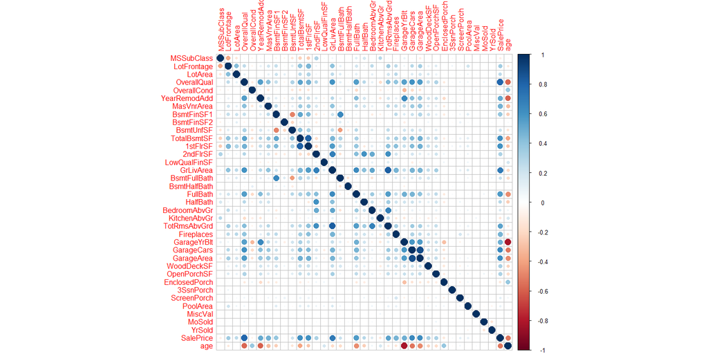

```r
corrplot(corr_matrix)
```

```r
colnames(melted_cormat) = c("Variables","Var2","correlation")
melted_cormat %>% filter(Var2 == "SalePrice") %>% arrange(-abs(correlation)) %>%
  slice(2:11) %>% select("Variables","correlation") -> max_cor
kable(max_cor)
```

| Variables | correlation |
| --- | --- |
| OverallQual | 0.7909816 |
| GrLivArea | 0.7086245 |
| GarageCars | 0.6404092 |
| GarageArea | 0.6234314 |
| TotalBsmtSF | 0.6135806 |
| 1stFlrSF | 0.6058522 |
| FullBath | 0.5606638 |
| TotRmsAbvGrd | 0.5337232 |
| age | -0.5228973 |
| YearRemodAdd | 0.5071010 |

۲. در یک تصویر نمودار پراکنش دو به دو ده متغیر بدست آمده به همراه قیمت را رسم نمایید و هم خطی بودن متغیرها را بررسی کنید

### پاسخ:

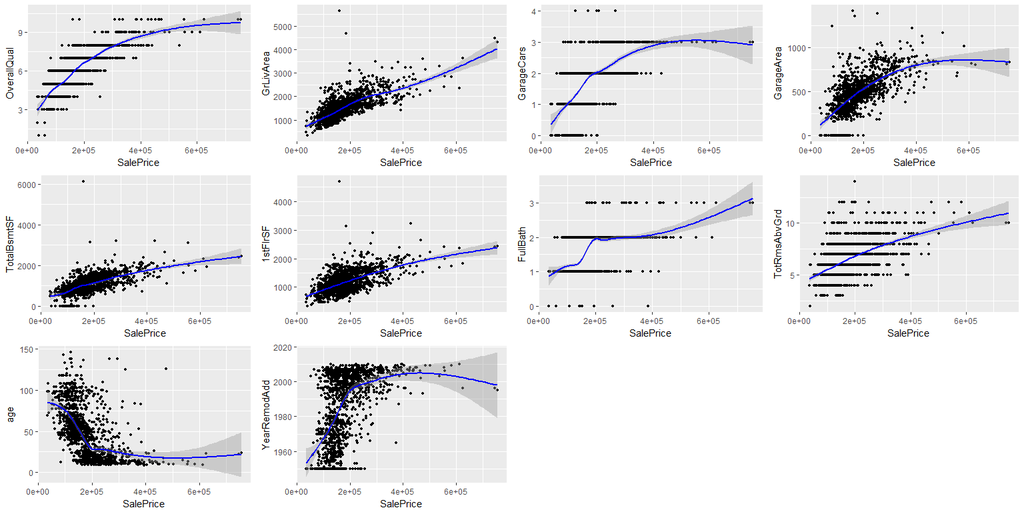

```r
p1 = ggplot(data = house,aes(x=SalePrice, y=house %>% select(as.character(max_cor$Variables[1]))))+
  ylab(as.character(max_cor$Variables[1]))+geom_point(size=1) +
  geom_smooth( formula=y~x, colour = "blue")
p2 = ggplot(data = house,aes(x=SalePrice, y=house %>% select(as.character(max_cor$Variables[2]))))+
  ylab(as.character(max_cor$Variables[2]))+geom_point(size=1) +
  geom_smooth( formula=y~x, colour = "blue")
p3 =  ggplot(data = house,aes(x=SalePrice, y=house %>% select(as.character(max_cor$Variables[3]))))+
  ylab(as.character(max_cor$Variables[3]))+geom_point(size=1) +
  geom_smooth( formula=y~x, colour = "blue")
p4 =  ggplot(data = house,aes(x=SalePrice, y=house %>% select(as.character(max_cor$Variables[4]))))+
  ylab(as.character(max_cor$Variables[4]))+geom_point(size=1) +
  geom_smooth( formula=y~x, colour = "blue")
p5 =  ggplot(data = house,aes(x=SalePrice, y=house %>% select(as.character(max_cor$Variables[5]))))+
  ylab(as.character(max_cor$Variables[5]))+geom_point(size=1) +
  geom_smooth( formula=y~x, colour = "blue")
p6 =  ggplot(data = house,aes(x=SalePrice, y=house %>% select(as.character(max_cor$Variables[6]))))+
  ylab(as.character(max_cor$Variables[6]))+geom_point(size=1) +
  geom_smooth( formula=y~x, colour = "blue")
p7 =  ggplot(data = house,aes(x=SalePrice, y=house %>% select(as.character(max_cor$Variables[7]))))+
  ylab(as.character(max_cor$Variables[7]))+geom_point(size=1) +
  geom_smooth( formula=y~x, colour = "blue")
p8 =  ggplot(data = house,aes(x=SalePrice, y=house %>% select(as.character(max_cor$Variables[8]))))+
  ylab(as.character(max_cor$Variables[8]))+geom_point(size=1) +
  geom_smooth( formula=y~x, colour = "blue")
p9 =  ggplot(data = house,aes(x=SalePrice, y=house %>% select(as.character(max_cor$Variables[9]))))+
  ylab(as.character(max_cor$Variables[9]))+geom_point(size=1) +
  geom_smooth( formula=y~x, colour = "blue")
p10 =  ggplot(data = house,aes(x=SalePrice, y=house %>% select(as.character(max_cor$Variables[10]))))+
  ylab(as.character(max_cor$Variables[10]))+geom_point(size=1) +
  geom_smooth( formula=y~x, colour = "blue")
grid.arrange(p1, p2, p3, p4,p5, p6, p7, p8, p9, p10, nrow=3)
```

نمودارها نشان می دهد که متغیرهای OverallQual، GrLivArea، TotalBsmtSF، 1stFlrSF و TotRmsAbvGrd بیشترین رابطه ی خطی را با قیمت دارند.

۳. یک مدل خطی بر اساس ده متغیر برای پیش بینی قیمت برازش دهید. و سپس خلاصه نتایج مدل را به دست آورید.

### پاسخ:

```r
fit = lm(SalePrice~ OverallQual + GrLivArea + GarageCars + GarageArea + TotalBsmtSF +
           `1stFlrSF`   + FullBath + TotRmsAbvGrd   + age + YearRemodAdd , data = house)
summary(fit)
```

```
##
## Call:
## lm(formula = SalePrice ~ OverallQual + GrLivArea + GarageCars +
##     GarageArea + TotalBsmtSF + `1stFlrSF` + FullBath + TotRmsAbvGrd +
##     age + YearRemodAdd, data = house)
##
## Residuals:
##     Min      1Q  Median      3Q     Max
## -489958  -19316   -1948   16020  290558
##
## Coefficients:
##                Estimate Std. Error t value Pr(>|t|)
## (Intercept)  -6.449e+05  1.254e+05  -5.141 3.11e-07 ***
## OverallQual   1.960e+04  1.190e+03  16.472  < 2e-16 ***
## GrLivArea     5.130e+01  4.233e+00  12.119  < 2e-16 ***
## GarageCars    1.042e+04  3.044e+03   3.422 0.000639 ***
## GarageArea    1.495e+01  1.031e+01   1.450 0.147384
## TotalBsmtSF   1.986e+01  4.295e+00   4.625 4.09e-06 ***
## `1stFlrSF`    1.417e+01  4.930e+00   2.875 0.004097 **
## FullBath     -6.791e+03  2.682e+03  -2.532 0.011457 *
## TotRmsAbvGrd  3.310e+01  1.119e+03   0.030 0.976404
## age          -2.682e+02  5.035e+01  -5.328 1.15e-07 ***
## YearRemodAdd  2.965e+02  6.363e+01   4.659 3.47e-06 ***
## ---
## Signif. codes:  0 '***' 0.001 '**' 0.01 '*' 0.05 '.' 0.1 ' ' 1
##
## Residual standard error: 37920 on 1449 degrees of freedom
## Multiple R-squared:  0.7737, Adjusted R-squared:  0.7721
## F-statistic: 495.4 on 10 and 1449 DF,  p-value: < 2.2e-16
```

۴. نمودار قیمت واقعی و قیمت پیش بینی را رسم نمایید و خوب بودن مدل را ارزیابی کنید.

### پاسخ:

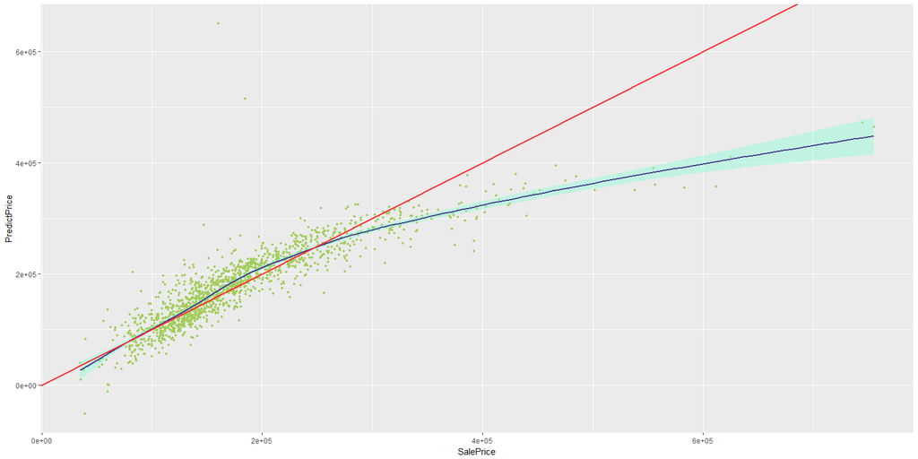

```r
stat %>% select(max_cor$Variables) -> stat
stat["PredictPrice"] = predict(fit,stat)
stat["SalePrice"] = house["SalePrice"]

ggplot(data = stat) + geom_point(aes(x = SalePrice , y = PredictPrice),
                                 size = 1 , color = "darkolivegreen3") +
  geom_smooth(aes(x = SalePrice , y = PredictPrice), formula=y~x, colour = "slateblue4",
              fill = "aquamarine") +
  geom_abline(slope = 1, intercept = 0, color = "firebrick1",size =1)
```

هرچه نمودار قیمت های پیش بینی شده بر حسب قیمت های اصلی، به خط با شیب 1 نزدیکتر باشد مدل خطی بهتر عمل کرده است. نمودار فوق نشان می دهد که مدل خطی ما، در قیمت های پایین تر که داده بیشتر بوده است پیش بینی نسبتا مناسبی داشته است ولی در قیمت های بالا که داده ها زیاد نبوده اند قیمت را کمتر از قیمت واقعی پیش بینی کرده است.

۵. مقدار R-squared مدل را به دست آورید. آیا بر اساس این کمیت مدل به خوبی به داده ها برازش داده شده است؟ کمیت F-statistic را در خلاصه مدل تفسیر نمایید.

### پاسخ:

```r
summary(fit)
```

```
##
## Call:
## lm(formula = SalePrice ~ OverallQual + GrLivArea + GarageCars +
##     GarageArea + TotalBsmtSF + `1stFlrSF` + FullBath + TotRmsAbvGrd +
##     age + YearRemodAdd, data = house)
##
## Residuals:
##     Min      1Q  Median      3Q     Max
## -489958  -19316   -1948   16020  290558
##
## Coefficients:
##                Estimate Std. Error t value Pr(>|t|)
## (Intercept)  -6.449e+05  1.254e+05  -5.141 3.11e-07 ***
## OverallQual   1.960e+04  1.190e+03  16.472  < 2e-16 ***
## GrLivArea     5.130e+01  4.233e+00  12.119  < 2e-16 ***
## GarageCars    1.042e+04  3.044e+03   3.422 0.000639 ***
## GarageArea    1.495e+01  1.031e+01   1.450 0.147384
## TotalBsmtSF   1.986e+01  4.295e+00   4.625 4.09e-06 ***
## `1stFlrSF`    1.417e+01  4.930e+00   2.875 0.004097 **
## FullBath     -6.791e+03  2.682e+03  -2.532 0.011457 *
## TotRmsAbvGrd  3.310e+01  1.119e+03   0.030 0.976404
## age          -2.682e+02  5.035e+01  -5.328 1.15e-07 ***
## YearRemodAdd  2.965e+02  6.363e+01   4.659 3.47e-06 ***
## ---
## Signif. codes:  0 '***' 0.001 '**' 0.01 '*' 0.05 '.' 0.1 ' ' 1
##
## Residual standard error: 37920 on 1449 degrees of freedom
## Multiple R-squared:  0.7737, Adjusted R-squared:  0.7721
## F-statistic: 495.4 on 10 and 1449 DF,  p-value: < 2.2e-16
```

کمیت R-squared نشان می دهد که برازش مدل تا چه حد دقیق است و هر چه قدر به 1 نزدیکتر باش برازش بهتر است. برای مدل فوق مقدار 0.77 به دست آمده که مقدار مناسبی است. F-Statistics آماره ی به دست آمده از آزمون فرضی است که فرض صفر آن صفر بودن تمام ضرایب مدل است یا به عبارتی معنادار بودن مدل رگرسیونی را به طور کلی تست می کند. با توجه به این که مقدار p-value این آزمون بسیار کوچک است، فرض صفر رد می شود و نشان می دهد که مدل رگرسیون به دست آمده به طور کلی معتبر است.

۶. بر اساس p-value سطح معناداری ضرایب تصمیم بگیرید که چه متغیرهایی در مدل سازی استفاده شود. بر اساس متغیرهای جدید دوباره مدل سازی کنید و نتایج رو گزارش دهید.

### پاسخ:

با توجه به signif codeهای به دست آمده از خلاصه ی مدل، متغیرهایی که ضرایبشان معنادارتر هستند را برای مدل جدید انتخاب می کنیم.

```r
fit = lm(SalePrice~ OverallQual + GrLivArea + GarageCars + TotalBsmtSF +
            age + YearRemodAdd , data = house)
summary(fit)
```

```
##
## Call:
## lm(formula = SalePrice ~ OverallQual + GrLivArea + GarageCars +
##     TotalBsmtSF + age + YearRemodAdd, data = house)
##
## Residuals:
##     Min      1Q  Median      3Q     Max
## -477106  -19737   -2015   16452  290098
##
## Coefficients:
##                Estimate Std. Error t value Pr(>|t|)
## (Intercept)  -6.071e+05  1.254e+05  -4.842 1.42e-06 ***
## OverallQual   1.912e+04  1.186e+03  16.123  < 2e-16 ***
## GrLivArea     5.036e+01  2.551e+00  19.743  < 2e-16 ***
## GarageCars    1.439e+04  1.813e+03   7.939 4.03e-15 ***
## TotalBsmtSF   3.086e+01  2.811e+00  10.979  < 2e-16 ***
## age          -2.211e+02  4.802e+01  -4.605 4.49e-06 ***
## YearRemodAdd  2.757e+02  6.353e+01   4.340 1.52e-05 ***
## ---
## Signif. codes:  0 '***' 0.001 '**' 0.01 '*' 0.05 '.' 0.1 ' ' 1
##
## Residual standard error: 38100 on 1453 degrees of freedom
## Multiple R-squared:  0.7709, Adjusted R-squared:   0.77
## F-statistic:   815 on 6 and 1453 DF,  p-value: < 2.2e-16
```

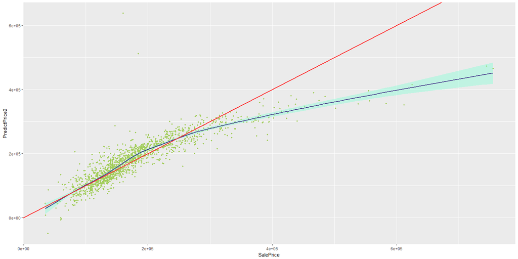

```r
stat["PredictPrice2"] = predict(fit,stat)


ggplot(data = stat) + geom_point(aes(x = SalePrice , y = PredictPrice2),
                                 size = 1 , color = "darkolivegreen3") +
  geom_smooth(aes(x = SalePrice , y = PredictPrice2), formula=y~x, colour = "slateblue4",
              fill = "aquamarine") +
  geom_abline(slope = 1, intercept = 0, color = "firebrick1",size =1)
```

با توجه به این که مقدار F-statistic بیشار شده است به طور کلی مدل معنادارتر است، گرچه چون تعداد متغیرها کاهش یافته است R-squared کاهش یافته است.

۷. مدل خود را بر اساس باقی مانده نقص یابی کنید. سه محک normality, independance, Constant Variance را در نقص یابی خود در نظر بگیرید.

### پاسخ:

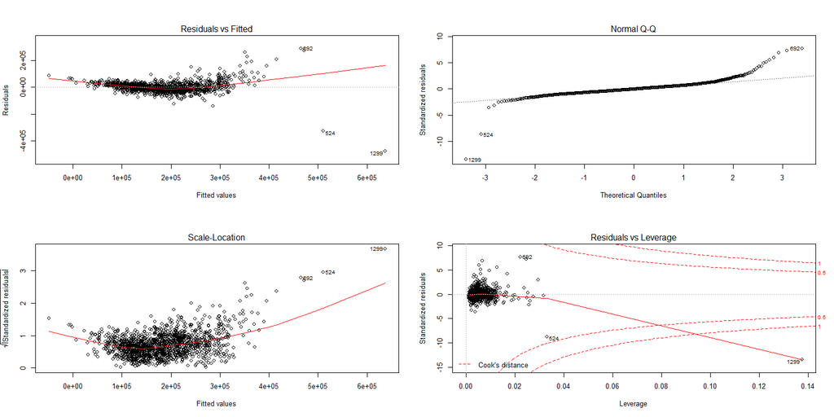

```r
#normality
#constant variance
par(mfrow=c(2,2))  # set 2 rows and 2 column plot layout
plot(fit)
```

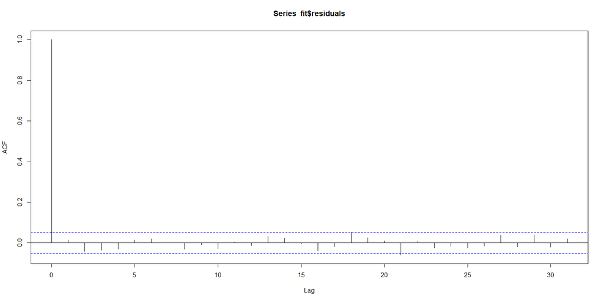

```r
# Method 1: Visualise with acf plot
acf(fit$residuals)
```

```r
#Method 2: Runs test to test for randomness
lawstat::runs.test(fit$residuals)
```

```
##
##  Runs Test - Two sided
##
## data:  fit$residuals
## Standardized Runs Statistic = -0.99485, p-value = 0.3198
```

نمودار فوق، autocorrelation مانده و تاخیر یافته های آن را نشان می دهد.با توجه به این که مقدار autocorrelation مانده با تاخیر یافته هایش بسیار کوچک است، فرض uncorrelated بودن مانده ها تایید می شود. هم چنین مقدار p-value به دست آمده از آزمون فرض runs هم این مطلب را تایید می کند.

۸. داده ها را به پنج قسمت تقسیم کنید. بر اساس چهار قسمت مدل خطی را بسازید و صحت مدل را برای یک قسمت باقی مانده را تست کنید. خطای پیش بینی شما چقدر است؟

### پاسخ:

```r
n = dim(house)[1]
train_indices =
  sample(1:n, size = n*0.8, replace = FALSE, prob = NULL)
test_indices = c(1:n)[-train_indices]

stat %>% select(-PredictPrice,-PredictPrice2) -> stat
train = stat[train_indices,]
test = stat[test_indices,]

fit = lm(SalePrice~ OverallQual + GrLivArea + GarageCars + TotalBsmtSF +
           age + YearRemodAdd , data = train)

summary(fit)
```

```
##
## Call:
## lm(formula = SalePrice ~ OverallQual + GrLivArea + GarageCars +
##     TotalBsmtSF + age + YearRemodAdd, data = train)
##
## Residuals:
##     Min      1Q  Median      3Q     Max
## -453512  -20126   -2174   16225  278461
##
## Coefficients:
##                Estimate Std. Error t value Pr(>|t|)
## (Intercept)  -5.949e+05  1.451e+05  -4.099 4.44e-05 ***
## OverallQual   2.034e+04  1.368e+03  14.867  < 2e-16 ***
## GrLivArea     4.865e+01  2.892e+00  16.822  < 2e-16 ***
## GarageCars    1.490e+04  2.041e+03   7.300 5.31e-13 ***
## TotalBsmtSF   2.671e+01  3.212e+00   8.318 2.48e-16 ***
## age          -2.259e+02  5.498e+01  -4.108 4.27e-05 ***
## YearRemodAdd  2.688e+02  7.354e+01   3.656 0.000268 ***
## ---
## Signif. codes:  0 '***' 0.001 '**' 0.01 '*' 0.05 '.' 0.1 ' ' 1
##
## Residual standard error: 39110 on 1161 degrees of freedom
## Multiple R-squared:  0.7616, Adjusted R-squared:  0.7604
## F-statistic: 618.2 on 6 and 1161 DF,  p-value: < 2.2e-16
```

```r
stat["PredictPrice"] = predict(fit,stat)

R2 = sum((stat$PredictPrice - mean(stat$SalePrice))^2)/
  sum((stat$SalePrice - mean(stat$SalePrice))^2)

Residual_standard_error = sqrt(mean((stat$PredictPrice - stat$SalePrice)^2))

R2
```

```
## [1] 0.7670012
```

```r
Residual_standard_error
```

```
## [1] 38055.69
```

۹. آیا قیمت ربط غیر خطی با یکی از ده متغیر استفاده شده دارد؟ بر اساس دستاوردهای خود مدل را بهتر نمایید.

### پاسخ:

با اضافه کردن عبارات غیر خطی به مدل، R-squared افزایش می یابد که نشان دهنده ی بهبود مدل است.

```r
fit1 = lm(SalePrice~ OverallQual*GrLivArea*GarageCars*TotalBsmtSF*age*YearRemodAdd , data = stat)
summary(fit1)
```

```
##
## Call:
## lm(formula = SalePrice ~ OverallQual * GrLivArea * GarageCars *
##     TotalBsmtSF * age * YearRemodAdd, data = stat)
##
## Residuals:
##     Min      1Q  Median      3Q     Max
## -164485  -13624    -182   12070  160652
##
## Coefficients:
##                                                                 Estimate
## (Intercept)                                                    8.177e+07
## OverallQual                                                   -1.508e+07
## GrLivArea                                                     -5.288e+04
## GarageCars                                                    -7.172e+07
## TotalBsmtSF                                                   -6.078e+04
## age                                                           -1.133e+06
## YearRemodAdd                                                  -4.113e+04
## OverallQual:GrLivArea                                          9.772e+03
## OverallQual:GarageCars                                         1.199e+07
## GrLivArea:GarageCars                                           4.098e+04
## OverallQual:TotalBsmtSF                                        1.107e+04
## GrLivArea:TotalBsmtSF                                          3.735e+01
## GarageCars:TotalBsmtSF                                         6.531e+04
## OverallQual:age                                                2.092e+05
## GrLivArea:age                                                  7.454e+02
## GarageCars:age                                                 9.127e+05
## TotalBsmtSF:age                                                9.928e+02
## OverallQual:YearRemodAdd                                       7.578e+03
## GrLivArea:YearRemodAdd                                         2.659e+01
## GarageCars:YearRemodAdd                                        3.610e+04
## TotalBsmtSF:YearRemodAdd                                       3.061e+01
## age:YearRemodAdd                                               5.701e+02
## OverallQual:GrLivArea:GarageCars                              -6.803e+03
## OverallQual:GrLivArea:TotalBsmtSF                             -6.761e+00
## OverallQual:GarageCars:TotalBsmtSF                            -1.057e+04
## GrLivArea:GarageCars:TotalBsmtSF                              -3.544e+01
## OverallQual:GrLivArea:age                                     -1.373e+02
## OverallQual:GarageCars:age                                    -1.512e+05
## GrLivArea:GarageCars:age                                      -5.188e+02
```

[output cut: 221 more lines]

```
## GrLivArea:TotalBsmtSF:age:YearRemodAdd                        ***
## GarageCars:TotalBsmtSF:age:YearRemodAdd                       ***
## OverallQual:GrLivArea:GarageCars:TotalBsmtSF:age              ***
## OverallQual:GrLivArea:GarageCars:TotalBsmtSF:YearRemodAdd     ***
## OverallQual:GrLivArea:GarageCars:age:YearRemodAdd             ***
## OverallQual:GrLivArea:TotalBsmtSF:age:YearRemodAdd            ***
## OverallQual:GarageCars:TotalBsmtSF:age:YearRemodAdd           ***
## GrLivArea:GarageCars:TotalBsmtSF:age:YearRemodAdd             ***
## OverallQual:GrLivArea:GarageCars:TotalBsmtSF:age:YearRemodAdd ***
## ---
## Signif. codes:  0 '***' 0.001 '**' 0.01 '*' 0.05 '.' 0.1 ' ' 1
##
## Residual standard error: 26390 on 1396 degrees of freedom
## Multiple R-squared:  0.8944, Adjusted R-squared:  0.8897
## F-statistic: 187.7 on 63 and 1396 DF,  p-value: < 2.2e-16
```

البته برای این که مدل، پارامترهای زیادی نداشته باشد و overfitting رخ ندهد نمودار همبستگی متغیرهای استفاده شده در مدل را رسم کرده و دو تا از آن ها که همبستگی خطی بالایی با سایر متغیرها دارند را حذف کرده و دو مدل دیگر هم روی داده ها آموزش می دهیم.

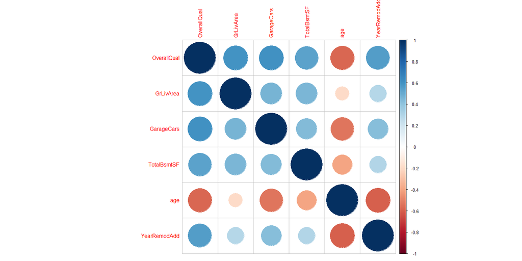

```r
corrplot(cor(stat %>% select(OverallQual,GrLivArea,GarageCars,TotalBsmtSF,age,YearRemodAdd)))
```

```r
fit2 = lm(SalePrice~ GrLivArea*GarageCars*TotalBsmtSF*YearRemodAdd , data = stat)
summary(fit2)
```

```
##
## Call:
## lm(formula = SalePrice ~ GrLivArea * GarageCars * TotalBsmtSF *
##     YearRemodAdd, data = stat)
##
## Residuals:
##     Min      1Q  Median      3Q     Max
## -323345  -15553    1005   16205  208813
##
## Coefficients:
##                                                 Estimate Std. Error t value
## (Intercept)                                   -4.089e+06  1.243e+06  -3.289
## GrLivArea                                      2.443e+03  9.668e+02   2.527
## GarageCars                                     5.744e+06  7.336e+05   7.830
## TotalBsmtSF                                    3.631e+03  1.367e+03   2.657
## YearRemodAdd                                   2.062e+03  6.269e+02   3.289
## GrLivArea:GarageCars                          -3.735e+03  5.332e+02  -7.005
## GrLivArea:TotalBsmtSF                         -2.213e+00  9.428e-01  -2.347
## GarageCars:TotalBsmtSF                        -5.181e+03  7.332e+02  -7.066
## GrLivArea:YearRemodAdd                        -1.195e+00  4.860e-01  -2.458
## GarageCars:YearRemodAdd                       -2.888e+03  3.693e+02  -7.821
## TotalBsmtSF:YearRemodAdd                      -1.783e+00  6.870e-01  -2.596
## GrLivArea:GarageCars:TotalBsmtSF               2.756e+00  4.807e-01   5.733
## GrLivArea:GarageCars:YearRemodAdd              1.879e+00  2.678e-01   7.019
## GrLivArea:TotalBsmtSF:YearRemodAdd             1.093e-03  4.722e-04   2.315
## GarageCars:TotalBsmtSF:YearRemodAdd            2.598e+00  3.681e-01   7.059
## GrLivArea:GarageCars:TotalBsmtSF:YearRemodAdd -1.376e-03  2.407e-04  -5.717
##                                               Pr(>|t|)
## (Intercept)                                    0.00103 **
## GrLivArea                                      0.01161 *
## GarageCars                                    9.36e-15 ***
## TotalBsmtSF                                    0.00797 **
## YearRemodAdd                                   0.00103 **
## GrLivArea:GarageCars                          3.78e-12 ***
## GrLivArea:TotalBsmtSF                          0.01904 *
## GarageCars:TotalBsmtSF                        2.48e-12 ***
## GrLivArea:YearRemodAdd                         0.01408 *
## GarageCars:YearRemodAdd                       1.00e-14 ***
## TotalBsmtSF:YearRemodAdd                       0.00953 **
## GrLivArea:GarageCars:TotalBsmtSF              1.20e-08 ***
## GrLivArea:GarageCars:YearRemodAdd             3.43e-12 ***
## GrLivArea:TotalBsmtSF:YearRemodAdd             0.02076 *
## GarageCars:TotalBsmtSF:YearRemodAdd           2.60e-12 ***
## GrLivArea:GarageCars:TotalBsmtSF:YearRemodAdd 1.31e-08 ***
## ---
## Signif. codes:  0 '***' 0.001 '**' 0.01 '*' 0.05 '.' 0.1 ' ' 1
##
## Residual standard error: 34260 on 1444 degrees of freedom
## Multiple R-squared:  0.8159, Adjusted R-squared:  0.814
## F-statistic: 426.8 on 15 and 1444 DF,  p-value: < 2.2e-16
```

```r
fit3 = lm(SalePrice~ (GrLivArea+GarageCars+TotalBsmtSF+YearRemodAdd)^2 , data = stat)
summary(fit3)
```

```
##
## Call:
## lm(formula = SalePrice ~ (GrLivArea + GarageCars + TotalBsmtSF +
##     YearRemodAdd)^2, data = stat)
##
## Residuals:
##     Min      1Q  Median      3Q     Max
## -366365  -15888     961   16491  273182
##
## Coefficients:
##                            Estimate Std. Error t value Pr(>|t|)
## (Intercept)               2.395e+06  3.731e+05   6.419 1.86e-10 ***
## GrLivArea                -1.362e+03  2.463e+02  -5.530 3.80e-08 ***
## GarageCars               -4.716e+05  1.498e+05  -3.149  0.00167 **
## TotalBsmtSF              -1.195e+03  2.887e+02  -4.139 3.69e-05 ***
## YearRemodAdd             -1.194e+03  1.901e+02  -6.281 4.44e-10 ***
## GrLivArea:GarageCars      2.418e+01  2.745e+00   8.808  < 2e-16 ***
## GrLivArea:TotalBsmtSF    -3.122e-02  2.001e-03 -15.598  < 2e-16 ***
## GrLivArea:YearRemodAdd    7.134e-01  1.251e-01   5.702 1.44e-08 ***
## GarageCars:TotalBsmtSF    1.599e+01  3.857e+00   4.147 3.57e-05 ***
## GarageCars:YearRemodAdd   2.219e+02  7.609e+01   2.916  0.00360 **
## TotalBsmtSF:YearRemodAdd  6.380e-01  1.473e-01   4.330 1.59e-05 ***
## ---
## Signif. codes:  0 '***' 0.001 '**' 0.01 '*' 0.05 '.' 0.1 ' ' 1
##
## Residual standard error: 35790 on 1449 degrees of freedom
## Multiple R-squared:  0.7984, Adjusted R-squared:  0.797
## F-statistic: 573.9 on 10 and 1449 DF,  p-value: < 2.2e-16
```

۱۰. بر اساس مدل نهایی به دست آمده نتایج پیش بینی خود را بر روی test.csv به دست آورید و در سایت kaggle در مسابقه House Prices: Advanced Regression Techniques بارگذاری نمایید. سپس لینک رتبه و عدد آن را ضمیمه تمرین کنید.

### پاسخ:

```r
test = read_csv("F:/University/8th Semester/Data Analysis/Class/Week 6/house/test.csv")
test %>% mutate(age = 2018 - YearBuilt) %>% select(Id,OverallQual, GrLivArea, GarageCars,
                                          TotalBsmtSF,age,YearRemodAdd )
```

```
## # A tibble: 1,459 x 7
##       Id OverallQual GrLivArea GarageCars TotalBsmtSF   age YearRemodAdd
##    <int>       <int>     <int>      <int>       <int> <dbl>        <int>
##  1  1461           5       896          1         882  57.0         1961
##  2  1462           6      1329          1        1329  60.0         1958
##  3  1463           5      1629          2         928  21.0         1998
##  4  1464           6      1604          2         926  20.0         1998
##  5  1465           8      1280          2        1280  26.0         1992
##  6  1466           6      1655          2         763  25.0         1994
##  7  1467           6      1187          2        1168  26.0         2007
##  8  1468           6      1465          2         789  20.0         1998
##  9  1469           7      1341          2        1300  28.0         1990
## 10  1470           4       882          2         882  48.0         1970
## # ... with 1,449 more rows
```

```r
test["SalePrice"] = predict(fit2,test)
test %>% select(Id,SalePrice) -> test
na_value = mean(test$SalePrice,na.rm = T)
test$SalePrice[661] = na_value
test$SalePrice[1117] = na_value
write_csv(test,"F:/University/8th Semester/Data Analysis/Class/Week 6/house/submission.csv")
```

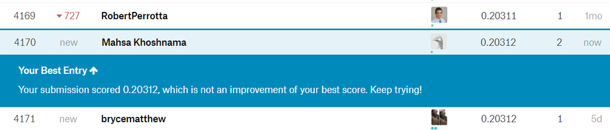